# Original and Modified Synthetic Control from scratch

Implementing Doudchenko, Imbens (2016)

Apoorva Lal

December 09, 2021

$\DeclareMathOperator*{\argmin}{argmin}$ $\newcommand{\norm}[1]{\left\Vert{#1} \right\Vert}$ $\newcommand{\var}{\mathrm{Var}}$ $\newcommand{\tra}{^{\top}}$ $\newcommand{\sumin}{\sum_{i=1}^n}$ $\newcommand{\sumiN}{\sum_{i=1}^n}$ $\newcommand{\epsi}{\varepsilon}$ $\newcommand{\phii}{\varphi}$ $\newcommand\Bigpar[1]{\left( #1 \right )}$ $\newcommand\Bigbr[1]{\left[ #1 \right ]}$ $\newcommand\Bigcr[1]{\left\{ #1 \right \}}$ $\newcommand\SetB[1]{\left\{ #1 \right\}}$ $\newcommand\Sett[1]{\mathcal{#1}}$ $\newcommand{\Data}{\mathcal{D}}$ $\newcommand{\Ubr}[2]{\underbrace{#1}_{\text{#2}}}$ $\newcommand{\Obr}[2]{ \overbrace{#1}^{\text{#2}}}$ $\newcommand{\sumiN}{\sum_{i=1}^N}$ $\newcommand{\dydx}[2]{\frac{\partial #1}{\partial #2}}$ $\newcommand\Indic[1]{\mathbb{1}_{#1}}$ $\newcommand{\Realm}[1]{\mathbb{R}^{#1}}$ $\newcommand{\Exp}[1]{\mathbb{E}\left[#1\right]}$ $\newcommand{\Expt}[2]{\mathbb{E}_{#1}\left[#2\right]}$ $\newcommand{\Var}[1]{\mathbb{V}\left[#1\right]}$ $\newcommand{\Covar}[1]{\text{Cov}\left[#1\right]}$ $\newcommand{\Prob}[1]{\mathbf{Pr}\left(#1\right)}$ $\newcommand{\Supp}[1]{\text{Supp}\left[#1\right]}$ $\newcommand{\doyx}{\Prob{Y \, |\,\mathsf{do} (X = x)}}$ $\newcommand{\doo}[1]{\Prob{Y |\,\mathsf{do} (#1) }}$ $\newcommand{\R}{\mathbb{R}}$ $\newcommand{\Z}{\mathbb{Z}}$ $\newcommand{\wh}[1]{\widehat{#1}} % Wide hat$ $\newcommand{\wt}[1]{\widetilde{#1}} % Wide tilde$ $\newcommand{\wb}[1]{\overline{#1}} % Wide bar$ $\newcommand\Ol[1]{\overline{#1}}$ $\newcommand\Ul[1]{\underline{#1}}$ $\newcommand\Str[1]{#1^{*}}$ $\newcommand{\F}{\mathsf{F}}$ $\newcommand{\ff}{\mathsf{f}}$ $\newcommand{\Cdf}[1]{\mathbb{F}\left(#1\right)}$ $\newcommand{\Cdff}[2]{\mathbb{F}_{#1}\left(#2\right)}$ $\newcommand{\Pdf}[1]{\mathsf{f}\left(#1\right)}$ $\newcommand{\Pdff}[2]{\mathsf{f}_{#1}\left(#2\right)}$ $\newcommand{\dd}{\mathsf{d}}$ $\newcommand\Normal[1]{\mathcal{N} \left( #1 \right )}$ $\newcommand\Unif[1]{\mathsf{U} \left[ #1 \right ]}$ $\newcommand\Bern[1]{\mathsf{Bernoulli} \left( #1 \right )}$ $\newcommand\Binom[1]{\mathsf{Bin} \left( #1 \right )}$ $\newcommand\Pois[1]{\mathsf{Poi} \left( #1 \right )}$ $\newcommand\BetaD[1]{\mathsf{Beta} \left( #1 \right )}$ $\newcommand\Diri[1]{\mathsf{Dir} \left( #1 \right )}$ $\newcommand\Gdist[1]{\mathsf{Gamma} \left( #1 \right )}$ $\def\mbf#1{\mathbf{#1}}$ $\def\mrm#1{\mathrm{#1}}$ $\def\mbi#1{\boldsymbol{#1}}$ $\def\ve#1{\mbi{#1}} % Vector notation$ $\def\vee#1{\mathbf{#1}} % Vector notation$ $\newcommand{\Mat}[1]{\mathbf{#1}}$ $\newcommand{\eucN}[1]{\norm{#1}}$ $\newcommand{\lzero}[1]{\norm{#1}_0}$ $\newcommand{\lone}[1]{\norm{#1}_1}$ $\newcommand{\ltwo}[1]{\norm{#1}_2}$ $\newcommand{\pnorm}[1]{\norm{#1}_p}$

- [Detailed Notes](https://apoorvalal.github.io/presentations/pdf/ImbensDoudchenko.pdf)

Data prep - Abadie et al (2015) German Reunification example

```r
# %% data prep
load('germany.RData')
x$country = factor(x$country)
pan = data.table(x)
pan[, treat := ifelse(country == "West Germany" & year >= 1990, 1, 0)]
treat_name = 'West Germany'
T0 = pan[country == "West Germany" & treat != 1, nunique(year)]
T1 = pan[country == "West Germany" & treat == 1, nunique(year)]
# number of post-treatment periods
# reshape to wide
wide = pan[, .(country, year, gdp)] |> dcast(year ~ country, value.var = 'gdp')
setcolorder(wide, c('year', treat_name))
y_treat_pre = wide[1:T0, 2] |> as.matrix()
y_ctrl_pre  = wide[1:T0, -(1:2)] |> as.matrix()
```

# Conceptual Setup from Doudchenko and Imbens (2016)

## Setup

- $N+1$ units observed for $T$ periods, with a subset of treated units (for simplicity - unit $0$) treated from $T_0$ onwards
- Treatment : $W_{i, t} = \Indic{i = 0 \; \land \; t \in {T_0 +1, \dots, T}}$
- Potential outcomes for unit $0$ define the treatment effect: $\tau_{0,t} := Y_{0,t}(1) - Y_{0,t}(0)$ for $t = T_0 + 1 , \dots, T$
- Observed outcome: $Y_{i,t}^{obs} = Y_{i,t}(W_{i,t})$

### Estimand and assumptions

# ADH(2010) Synthetic Control

```r
#' Solve for synthetic control weights in CVXR
#' @param y_t t_0 X 1   matrix of pre-treatment outcomes for treatment units
#' @param y_c t_0 X n_0 matrix of pre-treatment outcomes for donor units
#' @return vector of weights
#' @import CVXR
#' @export
sc_solve = function(y_t, y_c){
  ω = Variable(ncol(y_c))
  objective = Minimize(sum_squares(y_t - y_c %*% ω))
  constraints = list( # no intercept
    ω >= 0,            # positive weights
    sum(ω) == 1        # weights sum to 1
    )
  problem = Problem(objective, constraints)
  result = solve(problem, solver = 'MOSEK')
  ω_hat = result$getValue(ω)
  return(ω_hat)
}
# %%
ω_sc = sc_solve(y_treat_pre, y_ctrl_pre)
wt_table = data.frame(donor = colnames(y_ctrl_pre), wt = ω_sc)
# %% compute and plot
wide2 = copy(wide)
# impute Y(0) post for treated unit using weights
wide2$y0_sc = as.matrix(wide2[, -(1:2)]) %*% ω_sc
wide2$treat_effect = wide2[[treat_name]] - wide2$y0_sc
```

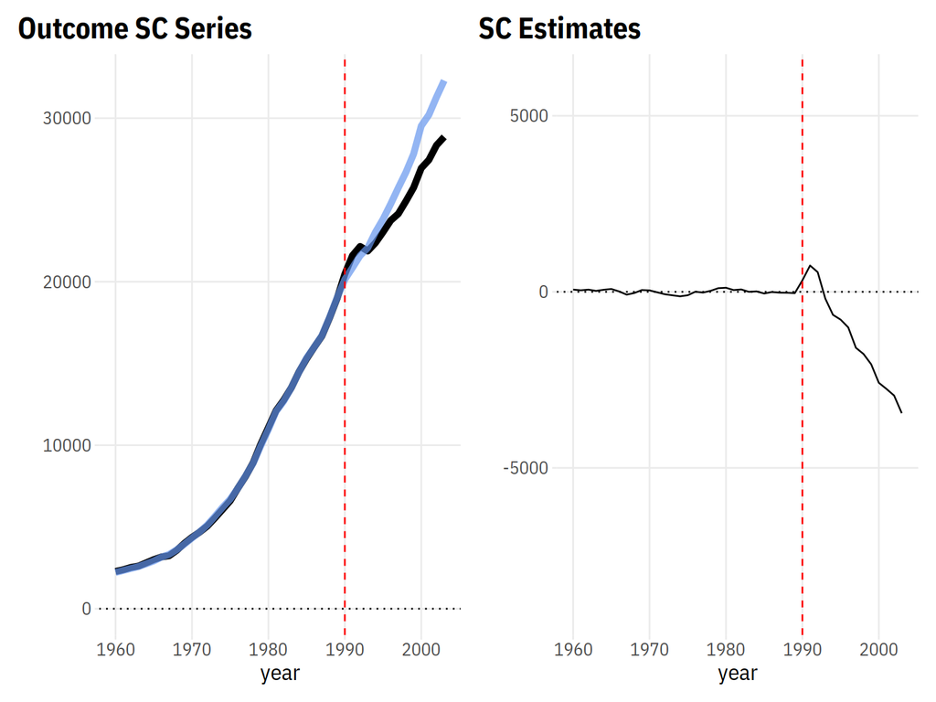

```r
# %%
sc_fit = ggplot(wide2, aes(year)) +
  geom_line(aes(y = `West Germany`), size = 2) +
  geom_line(aes(y = y0_sc), size = 2, alpha = 0.7, color = 'cornflowerblue') +
  geom_hline(yintercept = 0, linetype = "dotted") +
  geom_vline(xintercept = 1990, linetype = "dashed", color = 'red') +
  labs(title = "Outcome SC Series", y = "")

# %%
sc_est = ggplot(wide2, aes(year, treat_effect)) + geom_line() +
  geom_hline(yintercept = 0, linetype = "dotted") +
  geom_vline(xintercept = 1990, linetype = "dashed", color = 'red') +
  ylim(c(-9000, 6000)) +
  labs(title = "SC Estimates", y = "")

(sc_fit | sc_est)
```

# DI(2016) estimator

Relaxes all 4 assumptions. Use elastic-net to pick out small and sparse weights.

Desiderata: + **Balance**: difference between pre-treatment outcomes for treated and linear-combination of pre-treatment outcomes for control

$\ltwo{\Mat{Y}_{\text{t, pre}} - \mu - \omega \tra \Mat{Y}_{\text{c, pre}} }^2 = (\Mat{Y}_{\text{t, pre}} - \mu - \omega \tra \Mat{Y}_{\text{c, pre}}) \tra (\Mat{Y}_{\text{t, pre}} - \mu - \omega \tra \Mat{Y}_{\text{c, pre}})$

- **Sparse and small weights**:
  - sparsity : $\lone{\omega}$
  - magnitude: $\ltwo{\omega}$

$$\begin{align*}
(\wh{\mu}^{en} (\lambda, \alpha) , \wh{\omega}^{en}(\lambda, \alpha) ) & =
\argmin_{\mu, \omega} \; Q(\mu, \omega | \Mat{Y}_{\text{t, pre}}, \Mat{Y}_{\text{c, pre}}; \lambda, \alpha) \\
\text{where }\; \; Q(\mu, \omega | \Mat{Y}_{\text{t, pre}}, \Mat{Y}_{\text{c, pre}}; \lambda, \alpha) & =
\ltwo{
\Mat{Y}_{\text{t, pre}} - \mu - \omega \tra \Mat{Y}_{\text{c, pre}}
}^2 \\
+ & \; \; \lambda \Bigpar{\frac{1-\alpha}{2} \ltwo{\omega}^2 + \alpha
\lone{\omega} }
\end{align*}$$

## Elastic-Net Synthetic Control

```r
#' Solve for Imbens-Doudchenko elastic net synthetic control weights in CVXR
#' @param y_t t_0 X 1   matrix of pre-treatment outcomes for treatment units
#' @param y_c t_0 X n_0 matrix of pre-treatment outcomes for donor units
#' @param y_c t_0 X n_0 matrix of pre-treatment outcomes for donor units
#' @param lambdas       vector of penalty values
#' @param alpha         scalar mixing value between L1 and L2 regularisation
#' @param t             number of lambdas to try (when range not manually specified)
#' @return vector of weights
#' @import CVXR
#' @export
en_sc_solve = function(y_t, y_c, lambdas = NULL, alpha = 0.5, t = 10){
  # sequence of lambdas
  if (is.null(lambdas)) lambdas = 10^seq(-2, log10(max(y_t)), length.out = t)
  # penalty term
  elastic_penalty = function(ω, λ = 0, α = 0) {
      lasso =  cvxr_norm(ω, 1) * α
      ridge =  cvxr_norm(ω, 2) * (1 - α) / 2
      λ * (lasso + ridge)
  }
  # targets : intercept and weights
  μ = Variable(1) ; ω = Variable(ncol(y_c))
  en_solve = function(l) {
    obj = (sum_squares(y_t - μ - y_c %*% ω)/(2 * nrow(y_c)) +
            elastic_penalty(ω, l, alpha) )
    # unconstrained problem, just apply L1 and L2 regularisation to weights
    prob = Problem(Minimize(obj))
    sol = solve(prob, solver = 'MOSEK')
    sols = c(sol$getValue(μ), sol$getValue(ω))
  }
  # solve for each value of lambda
  solution_mat = lapply(lambdas, en_solve)
  # convert to (n_0 + 1) × |lambdas| matrix
  solution_mat = do.call(cbind, solution_mat)
  return(solution_mat)
}
```

Since we don’t have the coarse-regularisation induced by A2 + A3 any more, we need regularisation.

## Regularisation

- don’t want to scale covariates $\Mat{Y}_{\text{c, pre}}$ to preserve interpretability of weights
- Instead, treat each control unit as a `pseudo-treated’ unit and compute $\wh{Y}_{j, T}(0) = \wh{\mu}^{\text{en}}(j; \alpha, \lambda) + \sum_{i \neq j} \wh{\omega}_i (j; \alpha, \lambda) \cdot Y_{i,T}^{\text{obs}}$ where

$$\begin{align*}
(\wh{\mu}^{en} (j; \lambda, \alpha) , \wh{\omega}^{en}(j; \lambda, \alpha) ) & =
\argmin_{\mu, \omega} \; \sum_{t=1}^{T_0} \Bigpar{Y_{j,t} - \mu -
\sum_{i \neq 0, j} \omega_i Y_{i,t} }^2 + \\ & \lambda
\Bigpar{\frac{1-\alpha}{2} \ltwo{\omega}^2 + \alpha \lone{\omega} }
\end{align*}$$

pick the value of the tuning parameters $(\alpha_{opt}^{en}, \lambda_{opt}^{en})$ that minimises

$$CV^{en}(\alpha, \lambda) = \frac{1}{N} \sum_{j=1}^N ( Y_{j, T}
- \overbrace{
\wh{\mu}^{en}(j; \alpha, \lambda) - \sum_{i \neq 0, j}
\wh{\omega}_i^{en} (j; \alpha, \lambda) \cdot Y_{i,
T}}^{\wh{Y}_{j,T}(0)}
)$$

Currently sets $\alpha=0.5$ instead of tuning it. Can be relaxed readily, but doesn’t make much difference in this example.

```r
# %% pseudo-treatment prediction to pick λ
y_ctrl = wide[, -(1:2)] |> as.matrix() # all control units in matrix
lambdas = 10^seq(-1, log10(max(y_ctrl)), length.out = 20)
# %%
pick_lambda = function(j, Y, lambdas){
  # pre period data
  ypre = head(Y, T0)
  y_j  = ypre[, j]; y_nj = ypre[, -j]
  # fit μ, ω for pseudo-treatment unit
  ω_tilde = en_sc_solve(y_j, y_nj, lambdas)
  # compute prediction error on post-period
  ypost = tail(Y, T1)
  mse_j = function(w) mean(ypost[, j] - cbind(1, ypost[, -j])  %*% w)
  # each column in ω_tilde is a set of weights and intercepts for a given λ, so
  # summarise across columns
  mses = apply(ω_tilde, 2, mse_j)
  # lambda that minimises error
  lambdas[which(mses == min(mses))]
}

# %% # for small number of donors, can compute for all ; in other cases, pick randomly?
system.time(
  lam_choices <- mclapply(1:ncol(y_ctrl),
                        pick_lambda, y_ctrl,
                        10^seq(-1, log10(max(y_ctrl)), length.out = 20),
  mc.cores = 6
  )
)
# tabulate best lambda and pick the mode
lam_choices |> as.numeric() |> table()  |> sort() |> tail(1) |> names() |>
  as.numeric() |> round(2)
# %%
```

[output not shown]

Use the above $\lambda$ to fit Elastic-net synthetic control

```r
tic()
en_ω = en_sc_solve(y_treat_pre, y_ctrl_pre, 2517.62)
toc()
```

```
## 0.489 sec elapsed
```

```r
# %% compute and plot
wide3 = copy(wide)
# impute Y(0) post for treated unit using weights
wide3$y0_hat_en = as.matrix(cbind(1, wide3[, -(1:2)])) %*% en_ω
wide3$treat_effect = wide3[[treat_name]] - wide3$y0_hat_en

# %%
ensc_fit = ggplot(wide3, aes(year)) +
  geom_line(aes(y = `West Germany`), size = 2) +
  geom_line(aes(y = y0_hat_en), size = 2, alpha = 0.7, color = 'cornflowerblue') +
  geom_hline(yintercept = 0, linetype = "dotted") +
  geom_vline(xintercept = 1990, linetype = "dashed", color = 'red') +
  labs(title = "Outcome ENSC Series", y = "")

# %%
ensc_est = ggplot(wide3, aes(year, treat_effect)) + geom_line() +
  geom_hline(yintercept = 0, linetype = "dotted") +
  geom_vline(xintercept = 1990, linetype = "dashed", color = 'red') +
  ylim(c(-9000, 6000)) +
  labs(title = "ENSC Estimates", y = "")
```

# Comparing Results

## Figure

Results look very similar.

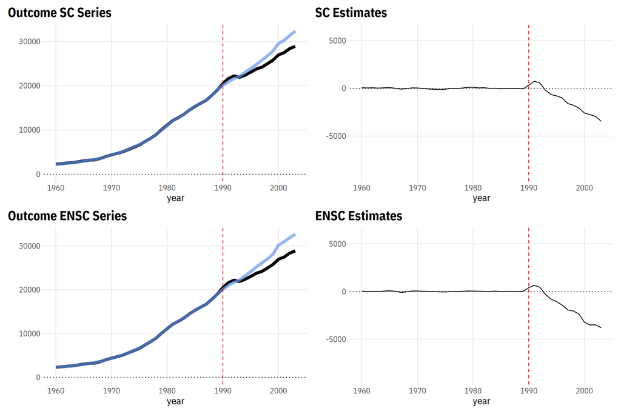

```r
(sc_fit | sc_est) / (ensc_fit | ensc_est)
```

## Weights

Elastic net weights are more dispersed and aren’t constrained to be positive. This appears not to matter in this example, but may help in others.

```r
wt_table2 = data.frame(
  donor = c('intercept', colnames(y_ctrl_pre)),
  wt_sc = c(0, round(ω_sc, 2)) ,
  wt_en =      round(en_ω, 2))
wt_table2 |> kable()
```

| donor | wt_sc | wt_en |
| --- | --- | --- |
| intercept | 0.00 | 296.98 |
| Australia | 0.00 | 0.00 |
| Austria | 0.32 | 0.27 |
| Belgium | 0.00 | 0.03 |
| Denmark | 0.00 | 0.00 |
| France | 0.04 | 0.05 |
| Greece | 0.10 | 0.13 |
| Italy | 0.06 | 0.28 |
| Japan | 0.00 | 0.00 |
| Netherlands | 0.00 | 0.01 |
| New Zealand | 0.00 | -0.04 |
| Norway | 0.03 | 0.09 |
| Portugal | 0.00 | 0.00 |
| Spain | 0.00 | -0.06 |
| Switzerland | 0.11 | 0.01 |
| UK | 0.00 | 0.00 |
| USA | 0.34 | 0.25 |